# Data Science Term Project

CSORNAI, Gyula - 134706

March 4, 2017

## Requirements

- Choose a publicly available dataset with at least 10,000 records and 10 variables.
- Do EDA, data cleaning
- Try several supervised learning methods (and several values for the parameters for each method).
- Do model selection and evaluation properly (train-test or cross validation etc.) Show various diagnostics (e.g. ROC curve for classification etc.)
- Discuss which algorithms work best on your data and possibly why.
- Bonus: Try the algorithms on the raw data without the cleaning. Are the results the same or worse?

## Modeling contains

- RF
- GBM with grid search
- SVM with grid search

## Data and origin

### Data description and relevance

Extraction was done by Barry Becker from the 1994 Census database. A set of reasonably clean records was extracted using the following conditions: ((AAGE>16) && (AGI>100) && (AFNLWGT>1)&& (HRSWK>0)) Prediction task is to determine whether a person makes over 50K a year.

### Data source

**Lichman, M. (2013).** *UCI Machine Learning Repository* [http://archive.ics.uci.edu/ml]. Irvine, CA: University of California, School of Information and Computer Science.

**Donor** Ronny Kohavi and Barry Becker Data Mining and Visualization Silicon Graphics.

## Exploratory data analysis

- age - The age of the individual
- work_class - The type of employer the individual has
- fnlwgt - The number of people the census takers believe that observation represents
- education - The highest level of education achieved for that individual
- eduY - Highest level of education in numerical form
- mar_stat - Marital status of the individual
- occupation - The occupation of the individual
- relationship - Contains family relationship values
- race - descriptions of the individuals race
- sex - Biological Sex in 2 base categories
- cap_gain - Capital gains recorded
- cap_loss - Capital Losses recorded
- hrpw - Hours worked per week
- nat_ctry - Country of origin for person
- mt50K - Whether or not the person makes more than $50,000 per annum income.

### Summary statistics of the data

Table continues below

| age | work_class | fnlwgt | education |
| --- | --- | --- | --- |
| Min. :17.00 | Private :22696 | Min. : 12285 | HS-grad :10501 |
| 1st Qu.:28.00 | Self-emp-not-inc: 2541 | 1st Qu.: 117827 | Some-college: 7291 |
| Median :37.00 | Local-gov : 2093 | Median : 178356 | Bachelors : 5355 |
| Mean :38.58 | ? : 1836 | Mean : 189778 | Masters : 1723 |
| 3rd Qu.:48.00 | State-gov : 1298 | 3rd Qu.: 237051 | Assoc-voc : 1382 |
| Max. :90.00 | Self-emp-inc : 1116 | Max. :1484705 | 11th : 1175 |
| NA | (Other) : 981 | NA | (Other) : 5134 |

Table continues below

| eduY | mar_stat | occupation |
| --- | --- | --- |
| Min. : 1.00 | Divorced : 4443 | Prof-specialty :4140 |
| 1st Qu.: 9.00 | Married-AF-spouse : 23 | Craft-repair :4099 |
| Median :10.00 | Married-civ-spouse :14976 | Exec-managerial:4066 |
| Mean :10.08 | Married-spouse-absent: 418 | Adm-clerical :3770 |
| 3rd Qu.:12.00 | Never-married :10683 | Sales :3650 |
| Max. :16.00 | Separated : 1025 | Other-service :3295 |
| NA | Widowed : 993 | (Other) :9541 |

Table continues below

| relationship | race | sex | cap_gain |
| --- | --- | --- | --- |
| Husband :13193 | Amer-Indian-Eskimo: 311 | Female:10771 | Min. : 0 |
| Not-in-family : 8305 | Asian-Pac-Islander: 1039 | Male :21790 | 1st Qu.: 0 |
| Other-relative: 981 | Black : 3124 | NA | Median : 0 |
| Own-child : 5068 | Other : 271 | NA | Mean : 1078 |
| Unmarried : 3446 | White :27816 | NA | 3rd Qu.: 0 |
| Wife : 1568 | NA | NA | Max. :99999 |
| NA | NA | NA | NA |

| cap_loss | hrpw | nat_ctry | mt50K |
| --- | --- | --- | --- |
| Min. : 0.0 | Min. : 1.00 | United-States:29170 | <=50K:24720 |
| 1st Qu.: 0.0 | 1st Qu.:40.00 | Mexico : 643 | >50K : 7841 |
| Median : 0.0 | Median :40.00 | ? : 583 | NA |
| Mean : 87.3 | Mean :40.44 | Philippines : 198 | NA |
| 3rd Qu.: 0.0 | 3rd Qu.:45.00 | Germany : 137 | NA |
| Max. :4356.0 | Max. :99.00 | Canada : 121 | NA |
| NA | NA | (Other) : 1709 | NA |

### Data cleaning

- Removing ? values
- Transforming output variable to factor
- Omitting fnlwgt: The number of people the census takers believe that observation represents.

### Data visualization

#### Single distribution of continuous variables

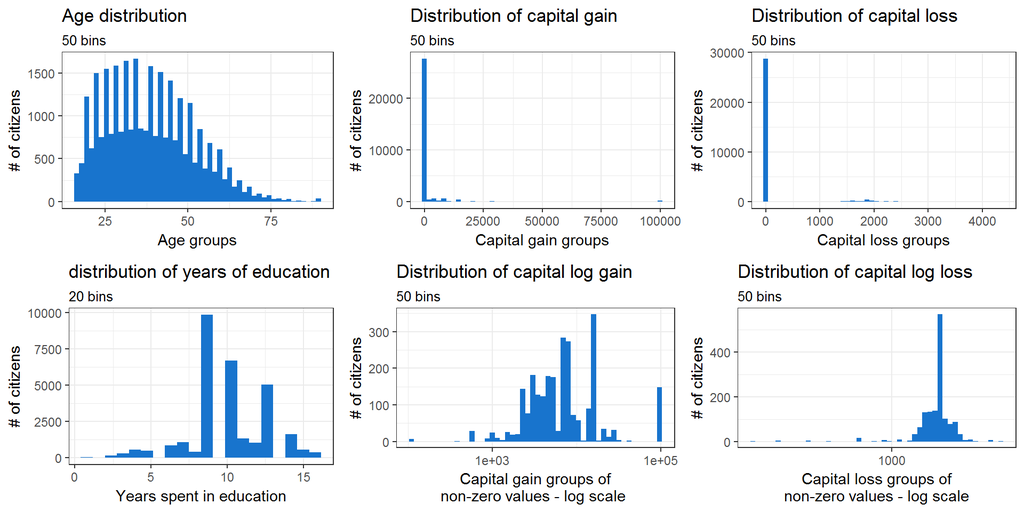

#### Single distributions of factors

##### Work and occupation

I expect work class to be a bad predictor (many categories, and most of the observation are in one category), occupation may be a relativel good one, because it does not have too many categories, and they are relatively homogenously populated.

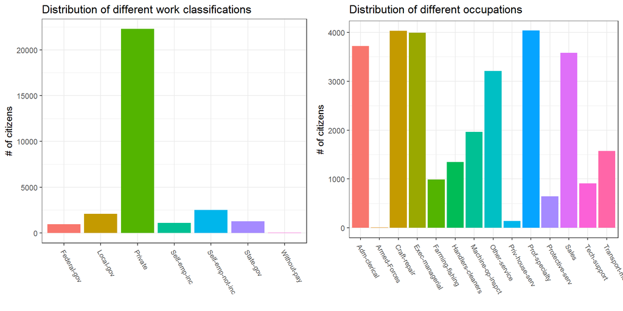

##### Education

Education is expected to be a medium-low predictor, because many education categories are not populated well, all are in 3 major categories. Corner cases may not be easily predicted.

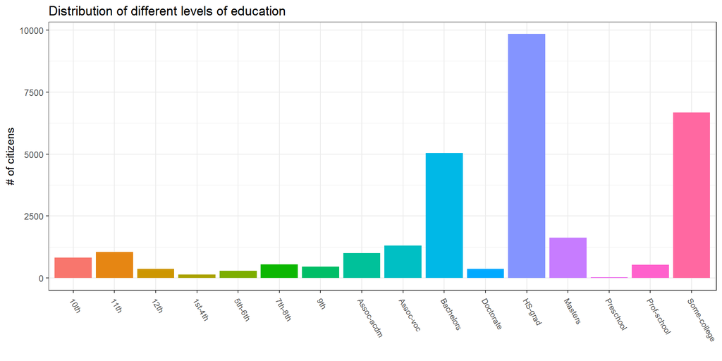

##### Personal data

From the following charts we can learn the following:

- Marital status may be a good candidate of strong predictor variable, because it has 2 major categories and a 3rd strong one.
- Race has a potential of not being a good predictor, because nealry all observations fall into the same category.
- Relationships from the other side may be a strong predictor, because the distribution is less skewed, we habe multiple well populated categories
- Sex may or may not be strong predictor, we have 2 categories only, and the dataset is unbalanced, we have twice as much males than females

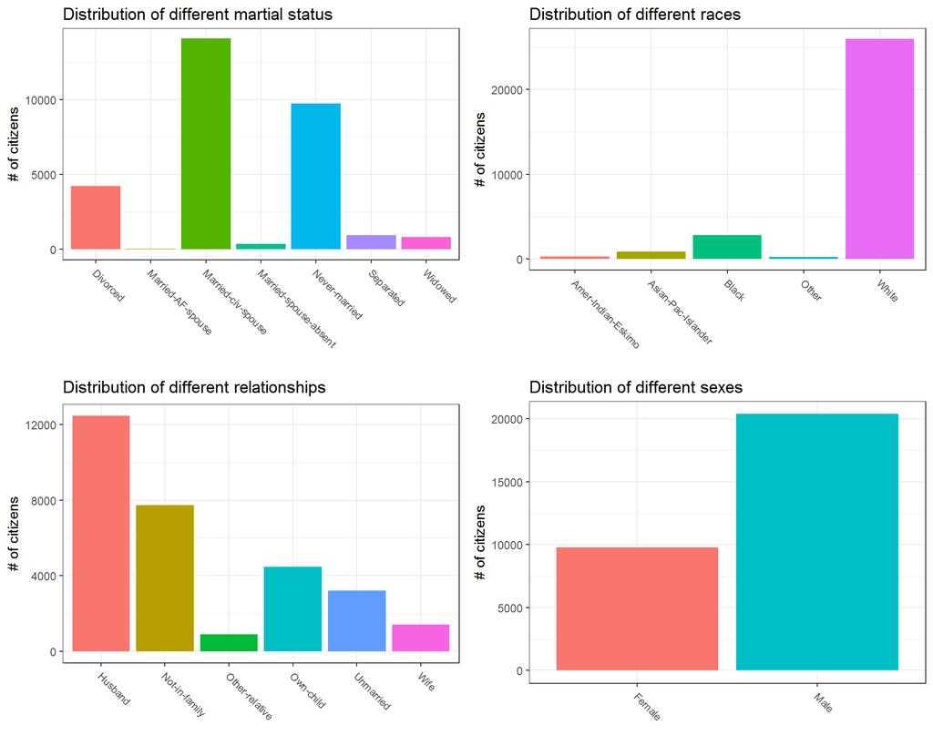

##### Original nationality

The following charts show, that nearly all observations fall into the same category, the majority of observations point to US nationality. This will not be a very strong predictor feature, because this feature is true for nearly all observations.

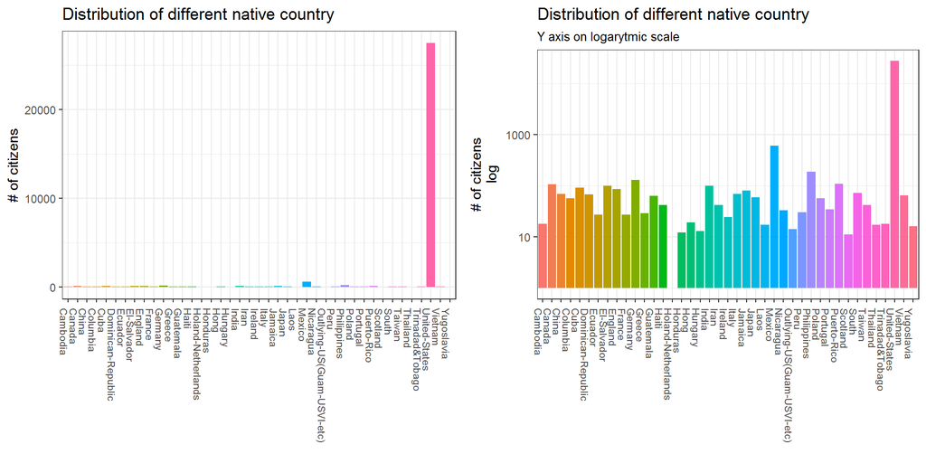

#### Wage category - the future prediction outcome

The dataset is not balanced, we have nearly 3 times as many observations under 50,000 USD compared to the ones over 50,000USD. This means, that we cannot simply rely on error rate, because predicting only under 50,000 will produce 25% error rate.

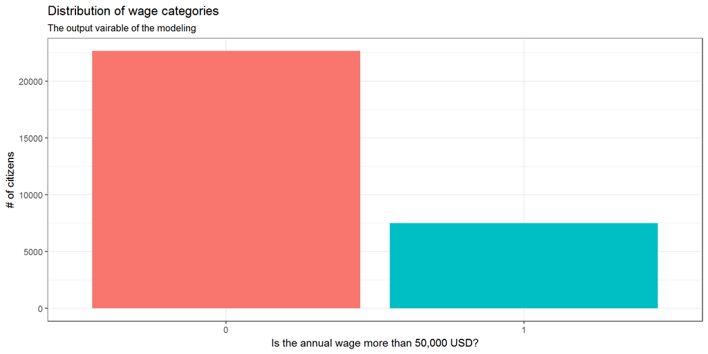

### Joint distributions of different variables

#### Discrete variables

When looking on joint distributions of discrete variables the following statements can be made:

- surprisingly marital status seems to be a good segmenter because it has a quite inhomogenous distribution
- occupation looks to be segmenting relatively poorly
- level of education segments better
- relationship segments better too
- work class seems to be on the lower end

This means, that whichever segments poorly will have a higher probability to predict badly in those tree models, where we are subsampling the variables.

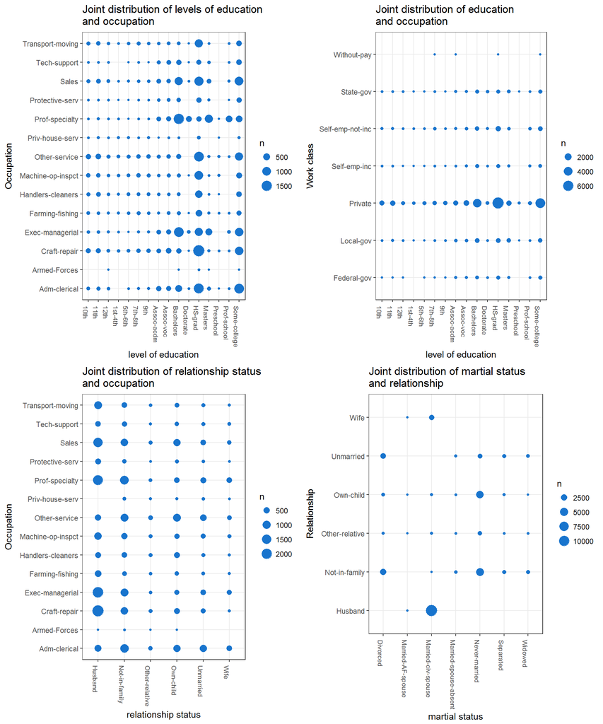

#### Continuous variables

##### Dependencies between age and capital by sex

The faceted charts below show, that if we try to differentiate between groups based on sex, both on capital gain and capital loss side the pattern will be relatively similar. This assumes that ses will not be a good predictor.

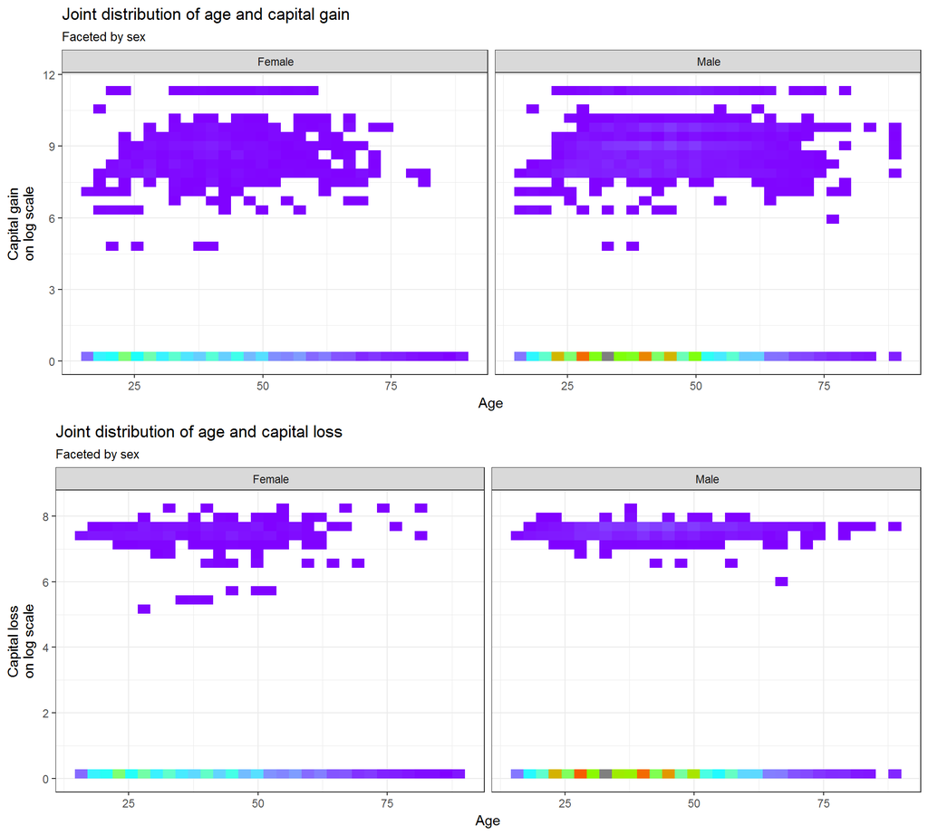

##### Dependencies between age and capital gain by work class

The joint distribution between age, capital gain and working class shows, that capital gain and working class produce somewhat different patterns, still the real differentiator is age. As shown above this is because the inbalance between the working class distributions - the majority of observations fall into private sector.

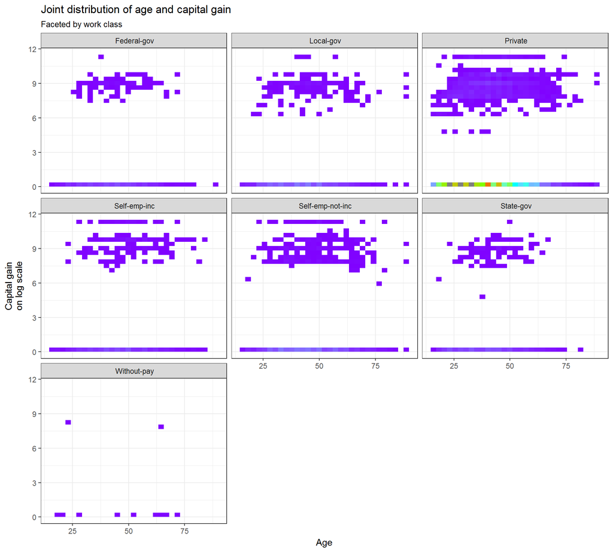

##### Dependencies between age and capital loss by work class

The joint distribution between age, capital loss and working class shows, that capital loss and working class produce relatively similar patterns and the real differentiator is age.

This means, that only age will be able to segment well in tree based algorythms, and in those cases where these 3 come together in the parameter selection, we will get poor prediction models.

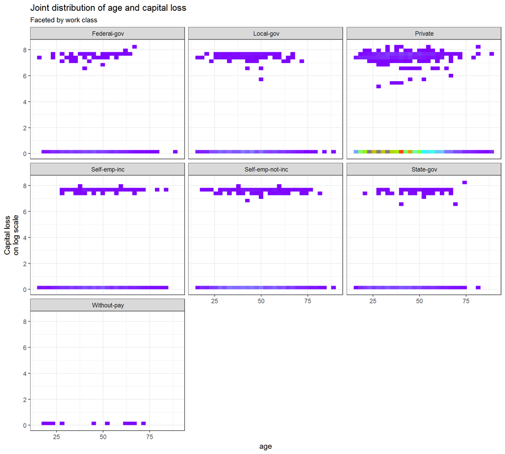

##### Dependencies between age and capital gain by education

The facet shows, that we can expect education to be a medium-good predictor together with capital gain, because from one side they segment the population to significantly different patterns, however the majority of the population shown on the heatmap with non-deep-blue colors are in 3 categories only:

- HS-Grad
- Some college
- Bachelors

Also we cannot expect significant capital gains in general in some low population degrees.

Age is going to be a good segmenter, which will be important in tree-based methods.

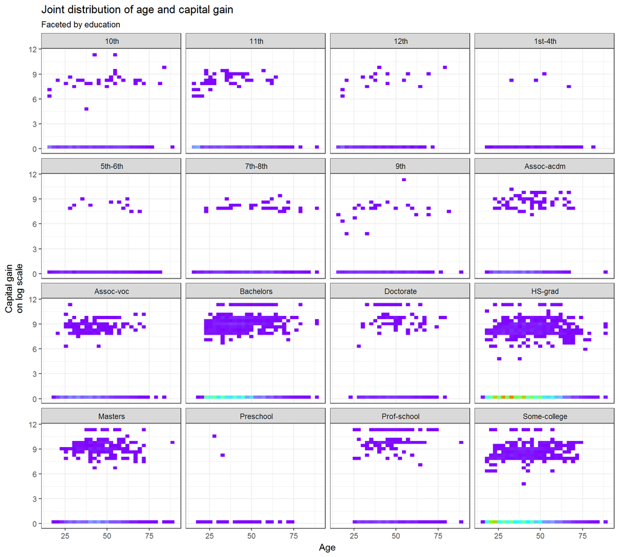

##### Dependencies between age and capital loss by education

The following faceted charts plots the joint distribution between age, capital loss and education

The facet shows, that we can expect education to be a medium-good predictor together with capital loss, because from one side they segment the population to somewhat different patterns, however the majority of the population shown on the heatmap with non-deep-blue colors are in 3 categories only:

- HS-Grad
- Some college
- Bachelors

From the other age here is still going to be a good segmenter, which will be important in tree-based methods.

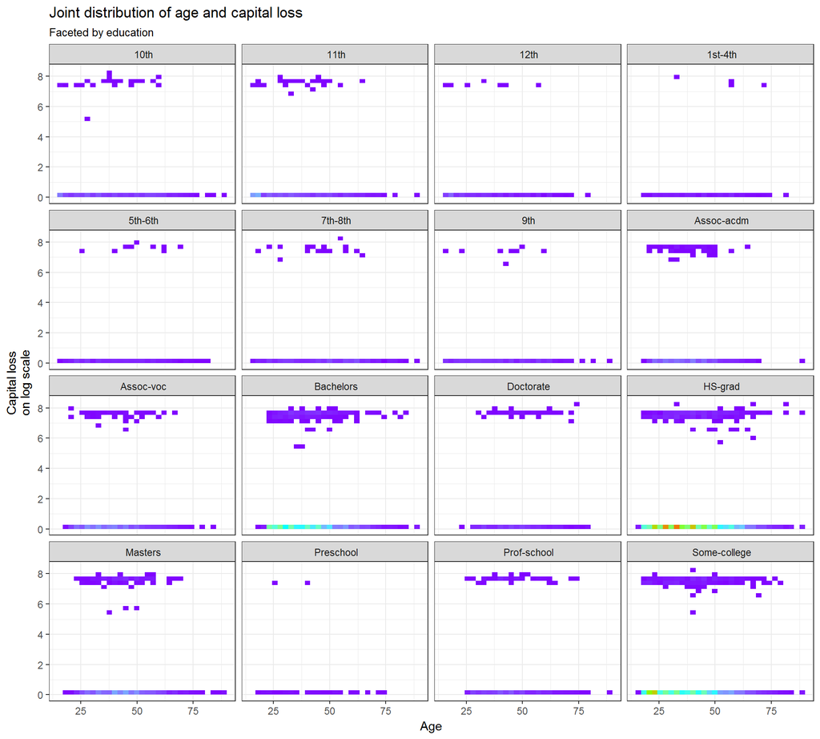

### Further feature engineering

I am dgoint to transform the capital gain and loss values in the following way:

$$lncg = log(capgain+1)$$
AND

$$lncl = log(caploss+1)$$

in order to normalize the distribution of the values. This is not a fundamental error, because the majority of the observed citizens have 0 capital gain and 0 capital loss, and whoever has some, has so much, that 1 USD per annum does not really count.

From this point on I will analyze the 2 versions separately, until I can figure it out, whether this transformation has helped or not.

```r
cdf$fnlwgt <- NULL
cdf$rnd <-runif(nrow(cdf))
cdf <- cdf[order(cdf$rnd),]
cdf$rnd <- NULL
cdfm <- cdf
cdfm$lncg <- log(cdfm$cap_gain + 1)
cdfm$lncl <- log(cdfm$cap_loss + 1)
cdfm$cap_gain <- NULL
cdfm$cap_loss <- NULL
```

## Supervised learning methods

### Analysis with Random forest

#### Modeling with 100 trees

##### Model details

The following chart shows the model details. The confusion matrix is not very descriptive, as it shows accuracy on the training set.

I acknowledge, that classification error is very low, in case the model predicts lower annual wage, than 50,000 USD, and it is significantly high, in case it tries to predict higher wage, than 50,000 USD. OBB estimate of error rate is relatively low.

Call: randomForest(formula = mt50K ~ ., data = train_nolog, ntree = 100, importance = TRUE) Type of random forest: classification Number of trees: 100 No. of variables tried at each split: 3

OOB estimate of error rate: 18.3299%

Confusion Matrix

|  | 0 | 1 | class.error |
| --- | --- | --- | --- |
| **0** | 15765 | 83 | 0.005237 |
| **1** | 3787 | 1478 | 0.7193 |

##### Model accuracy

|  | 0 | 1 |
| --- | --- | --- |
| **0** | 6784 | 1599 |
| **1** | 22 | 644 |

variables. The least important are:

- race
- sex
- original country where citizen came from.

The AUC is 0.8733052, which is an acceptable model.

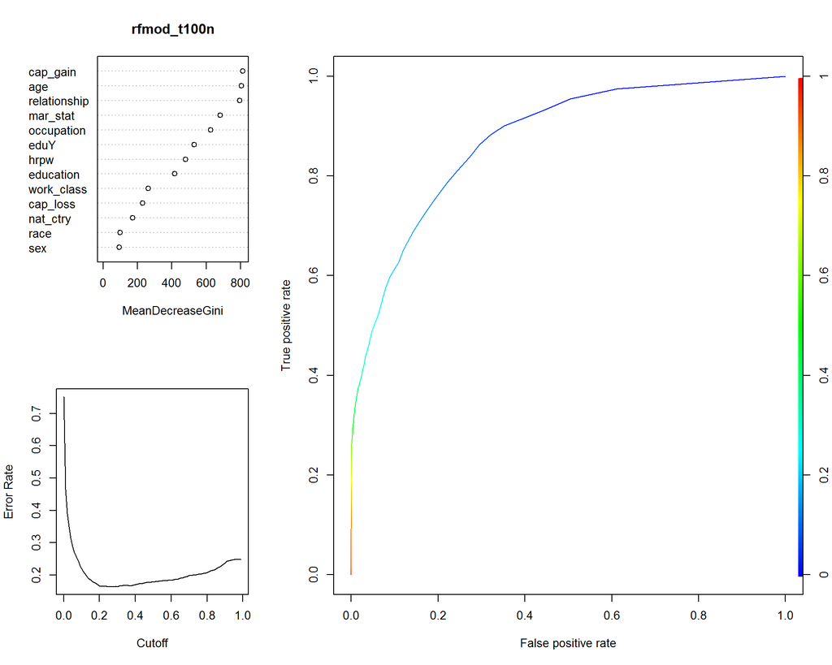

#### Modeling multiple random forest model versions

##### Comparison chart

| Model version / Performance | Error rate | AUC |
| --- | --- | --- |
| RF, ntree=100, cap.level, variable=3 | 17.9135816% | 0.8733052 |
| RF, ntree=100, cap.log, variable=3 | 18.0572439% | 0.8719526 |
| RF, ntree=500, cap.level, variable=3 | 17.9356835% | 0.8813217 |
| RF, ntree=500, cap.log, variable=3 | 17.9688363% | 0.8806689 |
| RF, ntree=500, cap.level, variable=5 | 17.9467344% | 0.8615107 |
| RF, ntree=500, cap.log, variable=5 | 17.9577854% | 0.859241 |

##### Kernel density functions

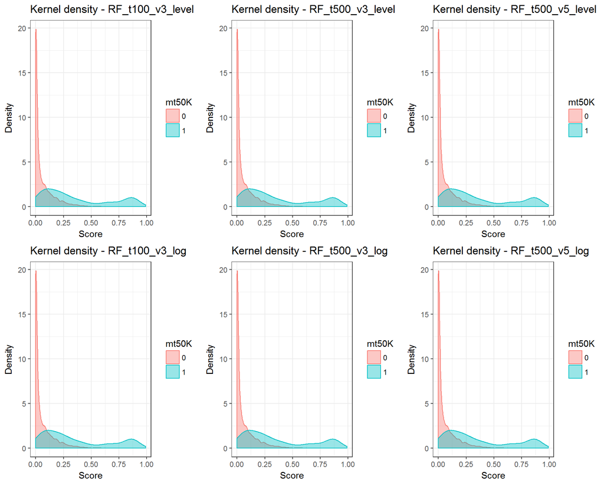

##### Importance of variables

After the first supervised analysis we can conclude, that relationship, capital gain (both level and log) and age are the most important predictors in all models, while native country, sex and race are not. This was somewhat expected from the distribution charts, however I expected occupation being in the top 3. There is also a surprising difference between the role of capital gain and capital loss, which was somewhat expected but not in this extent.

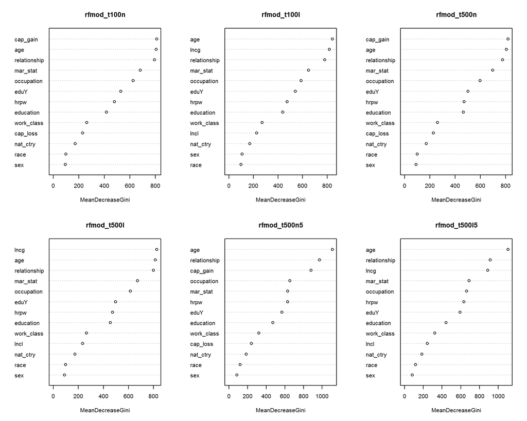

#### Conclusion for Random Forest

- The Random Forest algorythm gives acceptable quality, roboust results for all parameters.
- It does not really matter whether I use log or level value of capital gain
- In all versions the 2 major performance descriptors (error rate and AUC) were very close for each versions
- There is no visual difference in the kernel density functions
- All versions highlighted the same 3 variables as the most important, and the same 3 as the least important, only the importance was slightly different

### Analysis with GBM

Before modeling it is important to transform the output variable to number, because GBM can use numbers only.

GBM is the most sensitive model, when it comes to overfitting, but also promises the best performance in case used correctly.

Because of this there are 2 parameters I will primarily focus on:

- Interaction depth: the dept of the trees
- shrinkage: regularization parameter to control the gradient descent on error function surface.

#### Primary model

The primary model uses the following parameters:

- Number of trees = 100
- interaction depth = 10 - The depth of each tree
- shrinkage = 0.01 - Step size reduction in learning while descending on the error rate surface. 1 is full step. Typical shrinkage rates recommended are 0.01 to 0.001
- cv.folds = 5 - Uses 5 fold cross validation
- distribution = *bernoulli* - the loss function

Not yet used

- bag.fraction - subsampling rate

##### Confusion matrix

|  | 0 | 1 |
| --- | --- | --- |
| **0** | 6599 | 1166 |
| **1** | 207 | 1077 |

##### Learning curve

```
## Using cv method...
```

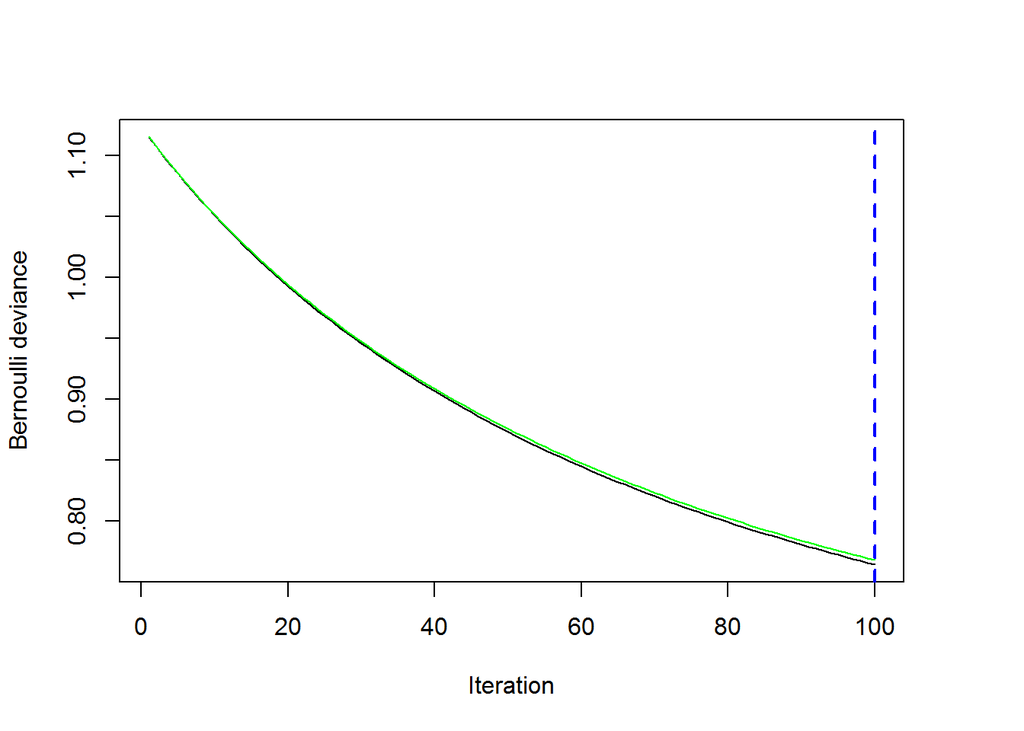

```
## [1] 100
```

#### Grid search with different parameters

##### Grid search table

| ModelID | Number of trees | Depth of each tree | Shrinkage | CV folds | Result TN | Result FN | Result FP | Result TP | AUC |
| --- | --- | --- | --- | --- | --- | --- | --- | --- | --- |
| gbm_p1 | 100 | 10 | 0.01 | 5 | 6599 | 1166 | 207 | 1077 | 0.9098608 |
| gbm_500_10_001_5 | 500 | 10 | 0.01 | 5 | 6440 | 838 | 366 | 1405 | 0.9243249 |
| gbm_100_20_001_5 | 100 | 20 | 0.01 | 5 | 6637 | 1179 | 169 | 1064 | 0.9170301 |
| gbm_500_20_001_5 | 500 | 20 | 0.01 | 5 | 6410 | 800 | 396 | 1443 | 0.9265779 |
| gbm_100_10_0001_5 | 100 | 10 | 0.001 | 5 | 6763 | 2286 | NA | NA | No positive results |
| gbm_500_10_0001_5 | 500 | 10 | 0.001 | 5 | 6804 | 1824 | 2 | 419 | 0.9065445 |
| gbm_100_20_0001_5 | 100 | 20 | 0.001 | 5 | 6763 | 2286 | NA | NA | No positive results |
| gbm_500_20_0001_5 | 500 | 20 | 0.001 | 5 | 6800 | 1709 | 6 | 534 | 0.9145492 |

##### Changing cross validation parameters

The following chart shows the impact of changing the folds of cross validation for the best model.

| ModelID | Number of trees | Depth of each tree | Shrinkage | CV folds | Result TN | Result FN | Result FP | Result TP | AUC |
| --- | --- | --- | --- | --- | --- | --- | --- | --- | --- |
| gbm_500_20_001_5 | 500 | 20 | 0.01 | 5 | 6410 | 800 | 396 | 1443 | 0.9265779 |
| gbm_500_20_001_1 | 500 | 20 | 0.01 | 1 | 6415 | 789 | 391 | 1454 | 0.9264738 |
| gbm_500_20_001_10 | 500 | 20 | 0.01 | 10 | 6421 | 780 | 385 | 1463 | 0.9268009 |
| gbm_500_20_001_3 | 500 | 20 | 0.01 | 3 | 6422 | 802 | 384 | 1441 | 0.926834 |

### Analysis with SVM

For support vector modeling classification the main direction was trying to fing appropriate gamma and cost parameters. SVM uses a certain step function (sigmoid, exponential) for prediction. Here gamma is the input parameter for non-linear kernel with 1/(data dimension) default value and cost is a regularization parameter with default value 1.

For all models above I used radial kernel.

My expectation fr SVM were robustness, but somewhat lower accuracy.

#### Primary model

The parameters of the primary model were:

- radial kernel
- gamma = 1 / 13 ~ 0.07692308
- cost=1

#### Grid search

| ModelID | kernel | Gamma | cost | epsilon | error rate | Result TN | Result FN | Result FP | Result TP | AUC |
| --- | --- | --- | --- | --- | --- | --- | --- | --- | --- | --- |
| base smv | radial | 1/13=0.07692308 | 1 | default=0.1 | 1 | 6781 | 1856 | 25 | 387 | 0.8888499 |
| smv2 | radial | 2^-7=0.0078125 | 2 | default=0.1 | 1 | 6800 | 2035 | 6 | 208 | 0.8949422 |
| smv3 | radial | 2^-3=0.125 | 2 | default=0.1 | 1 | 6773 | 1870 | 33 | 373 | 0.8798848 |
| smv4 | radial | 2^-1=0.5 | 2 | default=0.1 | 1 | 6768 | 1992 | 38 | 251 | 0.8566664 |
| smv5 | radial | 2^-3=0.125 | 1 | default=0.1 | 1 | 6775 | 1872 | 31 | 371 | 0.8857593 |
| smv5 | radial | 2^-3=0.125 | default=1 | 0.2 | 1 | 6783 | 1915 | 23 | 328 | 0.8922912 |

## Model selection

[output not shown]

## Discussion of effectiveness

- Random forest was a bit inaccurate, but was able to run on the dataset without issues (note: no factors have exceeded 53, which is RF limitation)
- GBM was the most accurate, but the cost was more feature engineering and in some cases model was not able to predict positive outcome
- SVM has very robust results, but the accuracy is lower, than GBM
- The price SVM and Random Forest pays in accuracy pays back in ranfom rorest inability to overfit and SVM also being a robust, not overfitting model.

## Appendix

### Notes about grid search based SVM tuning

I used manual grid search for all models instead of tune.svm or tune.randomForest. I gave an attempt to these software aider more detailed ones, but the modeling of the 5x5 or 7x7 models in case of SVM took such a long time (4+ hours) that I aborted them. I clearly reached a limitation of my local computer (Intel Core i5-6200U CPU @ 2.3GHz). This would have needed running on a stronger server.

### Notes about the performance

There is a possibility, that I could have achieved better performance model with ensembles. This however in time shortage I have not given an attempt in the scope of this project.

### Analysis with KNN

K-NearestNeighbour classification algorythm is a bit different from the tree models above, because it can handle only numeric input vectors. It uses Eucledian distance measure thereafter to calculate the “distance of the neighborhood”. From the other side it uses a factor for classification.

### 2-NN

The following table shows the confusion matrix, using the same (but transformed) train and test sets, using the 2 nearest neighbors for prediction.

|  | 0 | 1 |
| --- | --- | --- |
| **0** | 5956 | 850 |
| **1** | 841 | 1402 |

### 7-NN

The following table shows the confusion matrix, using the same (but transformed) train and test sets, using the 7 nearest neighbors for prediction.

|  | 0 | 1 |
| --- | --- | --- |
| **0** | 6188 | 618 |
| **1** | 870 | 1373 |

### 13-NN

The following table shows the confusion matrix, using the same (but transformed) train and test sets, using the 13 nearest neighbors for prediction.

|  | 0 | 1 |
| --- | --- | --- |
| **0** | 6233 | 573 |
| **1** | 922 | 1321 |

### Conclusion of KNN modeling

The following chart shows the results of the models. 2 neighbours show a higher error rate, however there is small difference between 7 and 13 neighbors. On this specific database KNN algorythm has produced surprisingly good results, despite of the fact that there was no real feature engineering and analysis how the distances between factor levels translate to Eucledian distance.

For a model which gives class as output, will be represented as a single point in ROC plot.

[output not shown]